# Pakiet mice

26 03 2020

## Wprowadzenie

MICE - Multivariate Imputation by Chained Equations (wielowymiarowa imputacja za pomocą równań łańcuchowych)

[figure not shown]

## Wykorzystanie

Pakiet mice zawiera funkcje służące do:

- generowania symulowanych niekompletnych danych
- sprawdzenia wzorca brakujących danych
- imputacji brakujących danych (wielokrotnie)
- diagnozowania jakości imputowanych wartości
- analizy każdego uzupełnionego zbioru danych
- zebrania wyników powtarzanych analiz
- przechowywania i eksportowania imputowanych danych w różnych formatach

## Główne funkcje

- `ampute()` Generowanie braków danych
- `mice()` Imputacja brakujących danych *m* razy
- `complete()` Eksport imputowanych danych
- `with()` Analiza uzupełnionych zbiorów danych
- `pool()` Łączenie szacowanych parametrów

## Zbiory danych dostępne w pakiecie mice

- `boys`
  - wzrost, waga, wiek … duńskich chłopców
- `brandsma`
  - dane o uczniach z różnych szkół
- `pattern1,2,3,4`
  - proste zbiory danych z różnymi wzorcami braków danych

## Generowanie braków danych

- funkcja `ampute`
- generowanie brakujących danych potrzebnych do symulacji
  - określony procent danych zostaje zastąpiony NA (obserwacje są wybierane losowo)
  - różne mechanizmy:

    ```
                MAR (Missing At Random),

                MCAR (Missing Completely At Random),

                MNAR (Missing Not At Random)
    ```

  - określenie wzorca braków danych oraz częstotliwości jego wystąpienia

```r
set.seed(1)
```

```r
iris_amp <- ampute(iris[,-5], prop = 0.5, mech = "MCAR")
```

## Sprawdzenie wzorca brakujących danych

Więkoszość metod do rysowania wykresów nadpisuje funkcje z pakietu `lattice`.

- `bwplot`
  - boxploty danych amputowanych i nieamputowanych
- `md.pattern`
  - wyświetlenie wzorca brakujących danych w formie wykresu (oraz tabeli - w konsoli)
- `fluxplot`

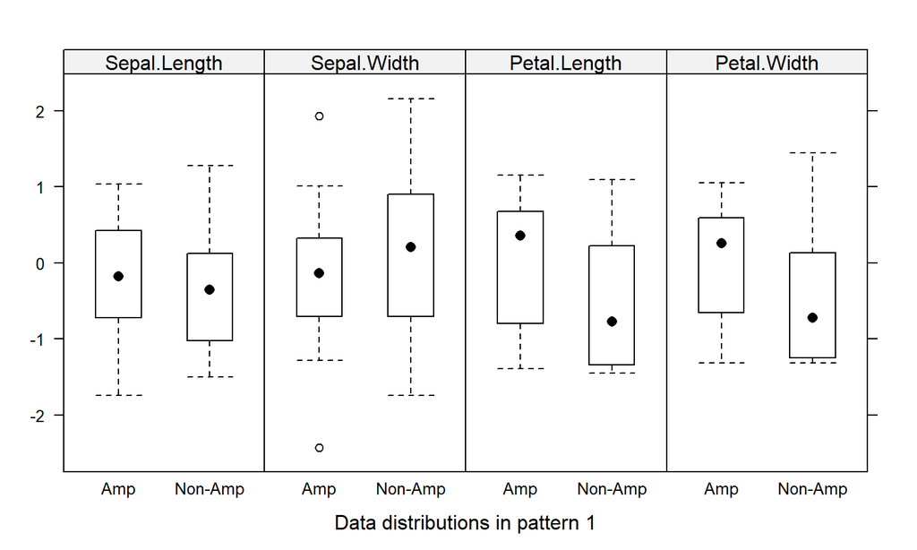

```r
mice::bwplot(iris_amp, which.pat = 1)
```

```r
md.pattern(iris_amp$amp,plot = FALSE, rotate.names = TRUE)
```

```
##    Petal.Width Petal.Length Sepal.Length Sepal.Width
## 84           1            1            1           1  0
## 19           1            1            1           0  1
## 19           1            1            0           1  1
## 17           1            0            1           1  1
## 11           0            1            1           1  1
##             11           17           19          19 66
```

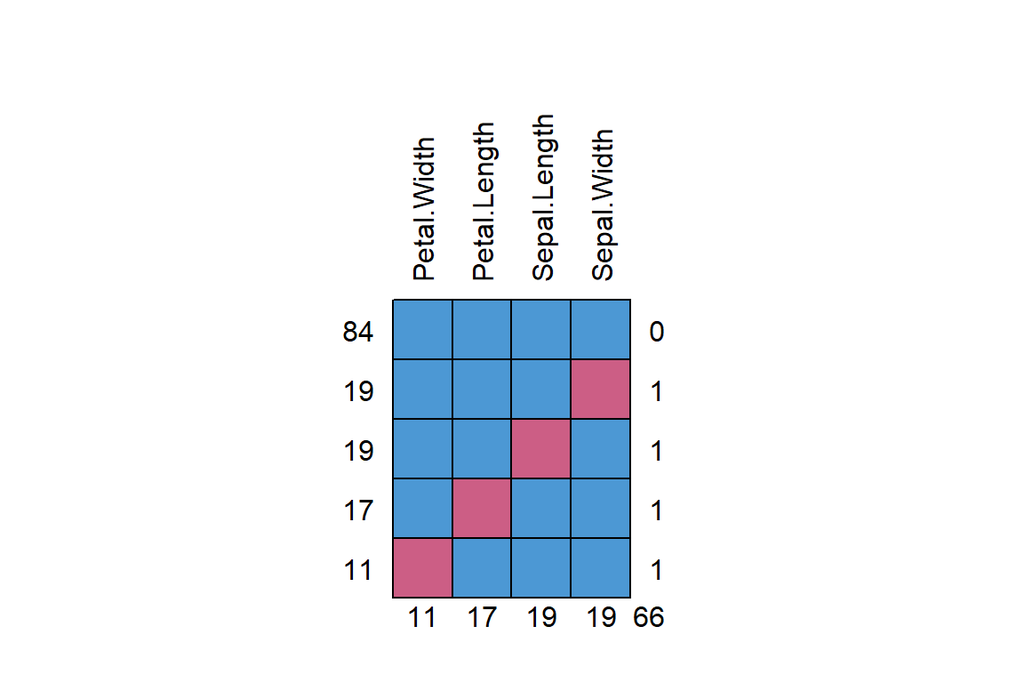

```r
md.pattern(iris_amp$amp, plot = TRUE, rotate.names = TRUE)
```

## Fluxplot

Dla każdej zmiennej obliczane są 2 wartości:

- Influx - liczba par zmiennych takich, że w danej jest brak a w drugiej nie, podzielona przez wszystkie obserwacje.

Dane pełne: 0

Dane całkowicie brakujące: 1

- Outflux - liczba par zmiennych takich, że w danej jest obserwacja a w drugiej brak, podzielona przez wszystkie obserwacje. Potencjalna użyteczność do imputowania innych zmiennych.

Dane pełne: 1

Dane całkowicie brakujące: 0.

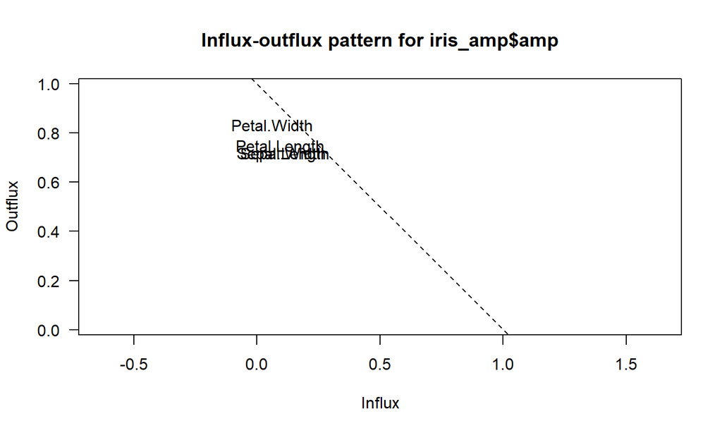

```r
fluxplot(iris_amp$amp)
```

## Imputacja danych

## Funkcja `mice`

Najważniejsze parametry:

- `data` - zbiór danych zawierający braki
- `m` - liczba imputacji (domyślnie 5)
- `method` - metoda imputacji
- `predictorMatix` - pozwala wskazać których kolumn użyć przy przewidywaniu wartości w danej kolumnie
- `where` - macierz binarna wskazująca gdzie imputować (domyślnie is.na(data))
- `defaultMethod` - określa domyślne metody stosowane dla poszczególnych typów danych
- `maxit` - liczba iteracji (domyślnie 5)

## Parametry `m` i `maxit`

```r
imp <- mice(boys, m=3, maxit=2)
```

## Klasa `mids` - multiply imputed data set

```r
imp
```

```
## Class: mids
## Number of multiple imputations:  3
## Imputation methods:
##       age       hgt       wgt       bmi        hc       gen       phb        tv
##        ""     "pmm"     "pmm"     "pmm"     "pmm"    "polr"    "polr"     "pmm"
##       reg
## "polyreg"
## PredictorMatrix:
##     age hgt wgt bmi hc gen phb tv reg
## age   0   1   1   1  1   1   1  1   1
## hgt   1   0   1   1  1   1   1  1   1
## wgt   1   1   0   1  1   1   1  1   1
## bmi   1   1   1   0  1   1   1  1   1
## hc    1   1   1   1  0   1   1  1   1
## gen   1   1   1   1  1   0   1  1   1
```

## Parametr `defaultMathod`

Parametr `defautMethod` funkcji mice określa domyślne metody stosowane dla poszczególnych typów danych, jeśli nie wskażemy jej wprost. Domyślnie jest to wektor:

defaultMethod = c(“pmm”, “logreg”, “polyreg”, “polr”)

## Parametr `method`

W zależności od typu brakujących danych, funkcja mice przyjmuje jako parametr inne metody imputacji danych.  
Dane podzielone są na 4 kategorie:

- dane numeryczne (ciągłe)
- dane binarne (dane typu factor z dwoma poziomami)
- nieuporządkowane dane kategoryczne (dane typu factor z więcej niż 2 poziomami)
- uporządkowane dane kategoryczne (dane typu factor z więcej niż 2 poziomami uporządkowanymi)

## Dowolne dane

Niektóre metody imputacji możemy zastosować do każdego typu danych.

- pmm (predictive mean matching) - predykcyjne dopasowanie średniej
- midastouch (weighted predictive mean matching)
- sample - losowa próbka
- cart (classification and regression trees) - drzewa klasyfikacyjne/regresji
- rf (random forest) - lasy losowe

## Dane numeryczne

- pmm (predictive mean matching) - domyślna
- mean - średnia
- norm (Bayesian linear regression/regresja liniowa)
  - norm.nob (linear regression ignoring model error)
  - norm.boot (linear regression using bootstrap)
  - norm.predict (linear regression, predicted values)
- quadratic (imputation of quadratic terms)
- ri (random indicator for nonignorable data)

## Predictive Mean Matching

Y - imputowana zmienna X - zbiór predykatorów (inne zmienne)

1. Regresja liniowa (używamy tylko zaobserwowanych wartości X i Y)
2. Wybieramy losowo z ‘posterior predictive distribution’ - rozkładu możliwych niezaobserwowanych wartości Y w zależności od zaobserowanych i tworzymy nowy zbiór współczynników.
3. Obliczamy osobno wartości dla zaobserowanych i brakujących Y
4. Dla każdej brakującej wartości Y, znajdujemy najbliższe (najczęściej 3) sprośród wartości dla zaobserowanych Y.
5. Wybieramy z nich jedną - losowo.

Bardzo dobre wyjaśnienie z przykładami w R:

https://statisticsglobe.com/predictive-mean-matching-imputation-method/?fbclid=IwAR04-2KA9LtMObQj062QRjgbDXIpGdgHWR-gmTMmIwLrVDITwjzSVuArK1c

## Zbiór danych boys

Zbiór zawiera już braki danych, ma kolumny:

- numeryczne
- kategoryczne uporządkowane
- kategoryczne nieuporządkowane

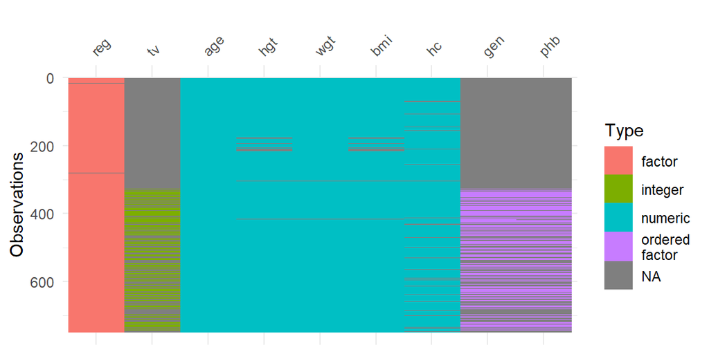

```r
visdat::vis_dat(boys)
```

Zaimputujemy kolumny numeryczne: 1,2,3,4,5 i 8

```r
dutch_boys<-boys
imp <- mice(dutch_boys[,c(1,2,3,4,5,8)],
            method="pmm", m=3, maxit=3)
dutch_boys[,c(1,2,3,4,5,8)] <- complete(imp)
```

## Metody wizualizacji danych imputowanych

- densityplot
- stripplot
- xyplot

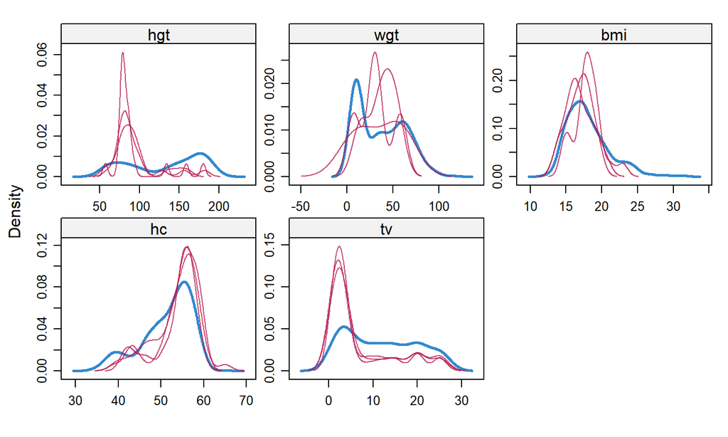

```r
densityplot(imp)
```

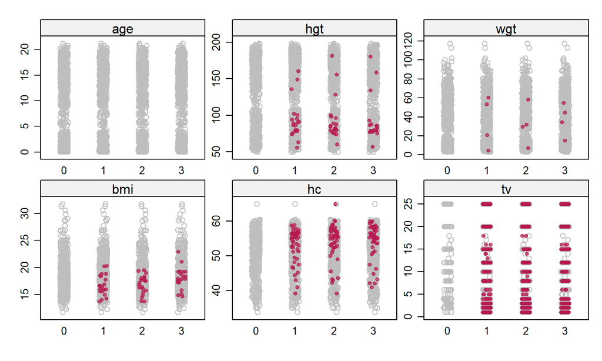

```r
stripplot(imp,col=c("grey",mdc(2)),pch=c(1,20))
```

## Nieuporządkowane dane kategoryczne

- polyreg (Polytomous logistic regression) - domyślna
- lda - liniowa analiza dyskryminacyjna

## Polyreg

Ugólnienie regresji logistycznej dla zmiennych o więcej niż 2 poziomach.

Więcej informacji: https://en.wikipedia.org/wiki/Multinomial_logistic_regression

Pozostała zmienna kategoryczna factor w kolumnie 9 (omijamy kolumny 6,7 innego typu, w których są jeszcze braki).

```r
imp <- mice(dutch_boys[,-c(6,7)], method="polyreg", m=3, maxit=3)
dutch_boys[,-c(6,7)] <- complete(imp)
```

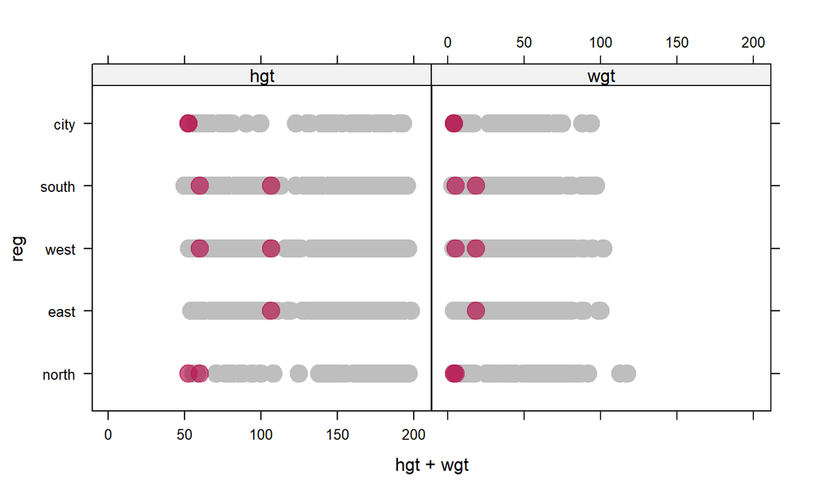

```r
xyplot(imp,reg ~ hgt+wgt,
       cex=3,col=c("grey",mdc(2)),pch=20)
```

## Uporządkowane dane kategoryczne

- polr (Proportional odds model) - domyślna

Model regresji dla danych kategorycznych uporządkowanych, opierający się na logarytmach odpowiednich proporacji. Np jeśli zmienna ma poziomy zły < średni < dobry < bardzo dobry, mające liczność odpowiednio \(p_1\),\(p_2\),\(p_3\),\(p_4\).

Logarytmy szansy, że ktoś odpowie w dany sposób wynosi:

zły - \(log(\frac{p_1}{p_2+p_3+p_4})\)

zły lub średni - \(log(\frac{p_1+p_2}{p_3+p_4})\)

zły, średni lub dobry - \(log(\frac{p_1+p_2+P_3}{p_4})\)

Więcej informacji: https://en.wikipedia.org/wiki/Ordered_logit

Dane kategoryczne uporządkowane znajdują się w kolumnach 6 i 7, ale wszystkie pozostałe kolumny są już uzupełnione.

```r
imp <- mice(dutch_boys, method="polr", m=3, maxit=3)
dutch_boys <- complete(imp)
```

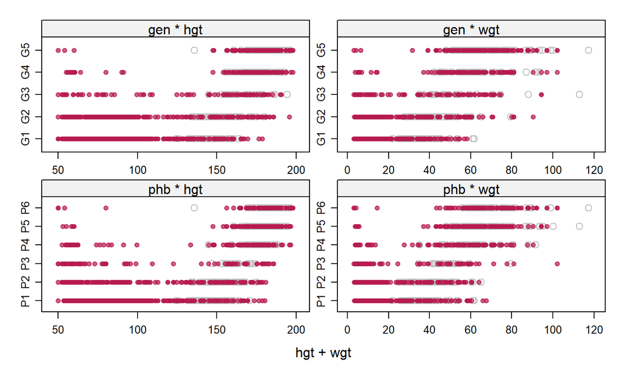

```r
xyplot(imp, gen+phb ~ hgt+wgt,
       cex=1,col=c("grey",mdc(2)),pch=c(1,20))
```

## Dane binarne

- logreg (logistic regression) - regresja logistyczna, domyślna
- logreg.boot (logistic regression with bootstrap)

## Logistic Regression

Stosowana, gdy zmienna ma tylko dwie kategorie, pozwala na obliczanie prawdopodobieństwa, że obserwacja należy do jednej z nich. Formalnie model regresji logistycznej jest uogólnionym modelem liniowym, w którym jako funkcji wiążącej używa się funkcji logit:

\(logit(p)=ln(\frac{p}{1-p})\)

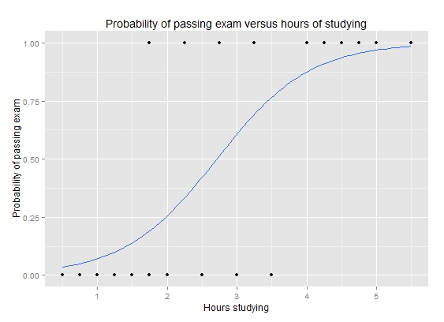

Więcej informacji: https://pl.wikipedia.org/wiki/Regresja_logistyczna

```r
mtcars_amp<-ampute(data=mtcars,
                   patterns=rbind(
                     c(1,1,1,1,1,1,1,0,1,1,1),
                     c(1,1,1,1,1,1,1,1,0,1,1)),
                   prop = 0.5,
                   mech="MCAR")$amp
mtcars_amp[,8] <- as.factor(mtcars_amp[,8])
mtcars_amp[,9] <- as.factor(mtcars_amp[,9])
```

```r
kable(summary(mtcars_amp) )
```

|  | mpg | cyl | disp | hp | drat | wt | qsec | vs | am | gear | carb |
| --- | --- | --- | --- | --- | --- | --- | --- | --- | --- | --- | --- |
|  | Min. :10.40 | Min. :4.000 | Min. : 71.1 | Min. : 52.0 | Min. :2.760 | Min. :1.513 | Min. :14.50 | 0 :14 | 0 :15 | Min. :3.000 | Min. :1.000 |
|  | 1st Qu.:15.43 | 1st Qu.:4.000 | 1st Qu.:120.8 | 1st Qu.: 96.5 | 1st Qu.:3.080 | 1st Qu.:2.581 | 1st Qu.:16.89 | 1 :11 | 1 : 8 | 1st Qu.:3.000 | 1st Qu.:2.000 |
|  | Median :19.20 | Median :6.000 | Median :196.3 | Median :123.0 | Median :3.695 | Median :3.325 | Median :17.71 | NA’s: 7 | NA’s: 9 | Median :4.000 | Median :2.000 |
|  | Mean :20.09 | Mean :6.188 | Mean :230.7 | Mean :146.7 | Mean :3.597 | Mean :3.217 | Mean :17.85 | NA | NA | Mean :3.688 | Mean :2.812 |
|  | 3rd Qu.:22.80 | 3rd Qu.:8.000 | 3rd Qu.:326.0 | 3rd Qu.:180.0 | 3rd Qu.:3.920 | 3rd Qu.:3.610 | 3rd Qu.:18.90 | NA | NA | 3rd Qu.:4.000 | 3rd Qu.:4.000 |
|  | Max. :33.90 | Max. :8.000 | Max. :472.0 | Max. :335.0 | Max. :4.930 | Max. :5.424 | Max. :22.90 | NA | NA | Max. :5.000 | Max. :8.000 |

```r
imp <- mice(mtcars_amp[,c(8,9)], method="logreg", m = 3, maxit = 3)
```

```r
mtcars_amp[,c(8,9)] <- complete(imp)
str(mtcars_amp)
```

```
## 'data.frame':    32 obs. of  11 variables:
##  $ mpg : num  21 21 22.8 21.4 18.7 18.1 14.3 24.4 22.8 19.2 ...
##  $ cyl : num  6 6 4 6 8 6 8 4 4 6 ...
##  $ disp: num  160 160 108 258 360 ...
##  $ hp  : num  110 110 93 110 175 105 245 62 95 123 ...
##  $ drat: num  3.9 3.9 3.85 3.08 3.15 2.76 3.21 3.69 3.92 3.92 ...
##  $ wt  : num  2.62 2.88 2.32 3.21 3.44 ...
##  $ qsec: num  16.5 17 18.6 19.4 17 ...
##  $ vs  : Factor w/ 2 levels "0","1": 2 1 2 2 1 2 1 2 2 2 ...
##  $ am  : Factor w/ 2 levels "0","1": 2 2 2 1 1 1 1 1 1 1 ...
##  $ gear: num  4 4 4 3 3 3 3 4 4 4 ...
##  $ carb: num  4 4 1 1 2 1 4 2 2 4 ...
```

## Zebranie wyników analiz

- `with`
  - dopasowanie modelu do każdego imputowanego zbioru na podstawie formuły
- `pool`
  - zebranie wyników wielokrotnej imputacji

```r
dutch_boys<-boys
temp <- mice(dutch_boys, m = 20, maxit = 5, seed = 123)
modelFit <- with(data=temp,
                 expr=lm(age ~ hgt + wgt))
```

```r
kable(summary(modelFit))
```

| term | estimate | std.error | statistic | p.value |
| --- | --- | --- | --- | --- |
| (Intercept) | -7.4516177 | 0.2393545 | -31.13214 | 0 |
| hgt | 0.1065174 | 0.0032617 | 32.65667 | 0 |
| wgt | 0.0715772 | 0.0058455 | 12.24489 | 0 |
| (Intercept) | -7.4670123 | 0.2399515 | -31.11885 | 0 |
| hgt | 0.1064355 | 0.0032611 | 32.63802 | 0 |
| wgt | 0.0719423 | 0.0058248 | 12.35101 | 0 |
| (Intercept) | -7.4558404 | 0.2417359 | -30.84292 | 0 |
| hgt | 0.1062040 | 0.0032909 | 32.27156 | 0 |
| wgt | 0.0725404 | 0.0058864 | 12.32346 | 0 |
| (Intercept) | -7.4359790 | 0.2423066 | -30.68831 | 0 |
| hgt | 0.1055910 | 0.0032888 | 32.10633 | 0 |
| wgt | 0.0738553 | 0.0058803 | 12.55981 | 0 |
| (Intercept) | -7.4691047 | 0.2416167 | -30.91303 | 0 |
| hgt | 0.1064579 | 0.0032883 | 32.37493 | 0 |
| wgt | 0.0720940 | 0.0058865 | 12.24744 | 0 |
| (Intercept) | -7.4172934 | 0.2432318 | -30.49475 | 0 |
| hgt | 0.1056611 | 0.0033131 | 31.89209 | 0 |
| wgt | 0.0734638 | 0.0059347 | 12.37873 | 0 |
| (Intercept) | -7.4262876 | 0.2405863 | -30.86745 | 0 |
| hgt | 0.1058270 | 0.0032785 | 32.27907 | 0 |
| wgt | 0.0730868 | 0.0058723 | 12.44612 | 0 |
| (Intercept) | -7.4723714 | 0.2425679 | -30.80528 | 0 |
| hgt | 0.1064441 | 0.0033005 | 32.25066 | 0 |
| wgt | 0.0721514 | 0.0059004 | 12.22814 | 0 |
| (Intercept) | -7.4844606 | 0.2431483 | -30.78147 | 0 |
| hgt | 0.1064027 | 0.0033023 | 32.22109 | 0 |
| wgt | 0.0723956 | 0.0058917 | 12.28775 | 0 |
| (Intercept) | -7.4766439 | 0.2421948 | -30.87037 | 0 |
| hgt | 0.1064583 | 0.0032969 | 32.29058 | 0 |
| wgt | 0.0721390 | 0.0059041 | 12.21849 | 0 |
| (Intercept) | -7.4526090 | 0.2426399 | -30.71469 | 0 |
| hgt | 0.1059929 | 0.0033015 | 32.10432 | 0 |
| wgt | 0.0730315 | 0.0059056 | 12.36659 | 0 |
| (Intercept) | -7.4486079 | 0.2408786 | -30.92266 | 0 |
| hgt | 0.1059531 | 0.0032718 | 32.38395 | 0 |
| wgt | 0.0730955 | 0.0058511 | 12.49252 | 0 |
| (Intercept) | -7.4250519 | 0.2419390 | -30.68976 | 0 |
| hgt | 0.1057957 | 0.0032953 | 32.10512 | 0 |
| wgt | 0.0731700 | 0.0058990 | 12.40387 | 0 |
| (Intercept) | -7.4751155 | 0.2425153 | -30.82327 | 0 |
| hgt | 0.1064283 | 0.0032999 | 32.25149 | 0 |
| wgt | 0.0721803 | 0.0059010 | 12.23193 | 0 |
| (Intercept) | -7.4850390 | 0.2407969 | -31.08445 | 0 |
| hgt | 0.1066884 | 0.0032747 | 32.57962 | 0 |
| wgt | 0.0716753 | 0.0058593 | 12.23280 | 0 |
| (Intercept) | -7.3666491 | 0.2402771 | -30.65898 | 0 |
| hgt | 0.1049471 | 0.0032668 | 32.12545 | 0 |
| wgt | 0.0746761 | 0.0058611 | 12.74102 | 0 |
| (Intercept) | -7.4956085 | 0.2408788 | -31.11775 | 0 |
| hgt | 0.1067501 | 0.0032812 | 32.53341 | 0 |
| wgt | 0.0716385 | 0.0058781 | 12.18730 | 0 |
| (Intercept) | -7.4462188 | 0.2445634 | -30.44699 | 0 |
| hgt | 0.1059348 | 0.0033264 | 31.84631 | 0 |
| wgt | 0.0731732 | 0.0059474 | 12.30334 | 0 |
| (Intercept) | -7.4602811 | 0.2423373 | -30.78470 | 0 |
| hgt | 0.1061860 | 0.0032981 | 32.19640 | 0 |
| wgt | 0.0725142 | 0.0058966 | 12.29774 | 0 |
| (Intercept) | -7.4555304 | 0.2412032 | -30.90975 | 0 |
| hgt | 0.1061588 | 0.0032868 | 32.29836 | 0 |
| wgt | 0.0726462 | 0.0058830 | 12.34856 | 0 |

```r
kable(summary(pool(modelFit)))
```

| term | estimate | std.error | statistic | df | p.value |
| --- | --- | --- | --- | --- | --- |
| (Intercept) | -7.4533661 | 0.2436020 | -30.59649 | 725.2071 | 0 |
| hgt | 0.1061417 | 0.0033196 | 31.97434 | 720.3581 | 0 |
| wgt | 0.0726524 | 0.0059418 | 12.22724 | 719.1528 | 0 |